# Purpose

## Purpose

The purpose of this package is to provide the infrastructure to store, represent and exchange the gated flow data. By this we mean, accessing the samples, groups, transformations, compensation matrices, gates, and population statistics in the gating tree, which is represented as `GatingSet` object in `R`.

The `GatingSet` can be built from scratch within `R` or imported from `flowJo` XML workspaces (i.e. `.xml` or `.wsp` files) or `GatingML` files . Note that we cannot import `.jo` files directly. You will have to save them in XML workspace format.

## Import flowJo workspace

The following section walks through opening and importing a flowJo workspace.

### Opening a Workspace

We represent flowJo workspaces using `flowJoWorkspace` objects. We only need to know the path to, and filename of the flowJo workspace.

```r
library(flowWorkspace)
path <- system.file("extdata",package="flowWorkspaceData");
wsfile <- list.files(path, pattern="A2004Analysis.xml", full = TRUE)
```

In order to open this workspace we call:

```r
ws <- openWorkspace(wsfile)
ws
```

```
## FlowJo Workspace Version  2.0
## File location:  /home/biocbuild/bbs-3.6-bioc/R/library/flowWorkspaceData/extdata
## File name:  A2004Analysis.xml
## Workspace is open.
##
## Groups in Workspace
##          Name Num.Samples
## 1 All Samples           2
```

We see that this a version 2.0 workspace file. It's location and filename are printed. Additionally, you are notified that the workspace file is open. This refers to the fact that the XML document is internally represented using 'C' data structures from the `XML` package. After importing the file, the workspace must be explicitly closed using `closeWorkspace()` in order to free up that memory.

With the workspace file open,some basic sample information can be accessed through some helper methods. For example, the list of samples in a workspace can be accessed by:

```r
getSamples(ws)
```

```
##   sampleID                       name count compID pop.counts
## 1        1 a2004_O1T2pb05i_A1_A01.fcs 61832      1         19
## 2        2 a2004_O1T2pb05i_A2_A02.fcs 45363      1         19
```

The `compID` column tells you which compensation matrix to apply to a group of files, and similarly, based on the name of the compensation matrix, which transformations to apply.

And the groups can be accessed by:

```r
getSampleGroups(ws)
```

```
##     groupName groupID sampleID
## 1 All Samples       0        1
## 2 All Samples       0        2
```

Keywords stored in xml workspace can also retrieved by:

```r
sn <- "a2004_O1T2pb05i_A1_A01.fcs"
getKeywords(ws, sn)[1:5]
```

```
## $`$BEGINANALYSIS`
## [1] "0"
##
## $`$BEGINDATA`
## [1] "3803"
##
## $`$BEGINSTEXT`
## [1] "0"
##
## $`$BTIM`
## [1] "09:20:24"
##
## $`$BYTEORD`
## [1] "4,3,2,1"
```

### Parsing the Workspace

These are all retrieved by directly querying xml file. In order to get more information about the gating tree, we need to actually parse the XML workspace into R data structures to represent some of the information therein. Specifically, by calling `parseWorkspace()` the user will be presented with a list of `groups` in the workspace file and need to choose one group to import. Why only one? Because of the way flowJo handles data transformation and compensation. Each group of samples is associated with a compensation matrix and specific data transformation. These are applied to all samples in the group. When a particular group of samples is imported, the package generates a `GatingHierarchy` for each sample, describing the set of gates applied to the data (note: polygons, rectangles, quadrants, and ovals and boolean gates are supported). The set of GatingHierarchies for the group of samples is stored in a `GatingSet` object. Calling `parseWorkspace()` is quite verbose, informing the user as each gate is created. The parsing can also be done non–interactively by specifying which group to import directly in the function call (either an index or a group name). An additional optional argument `execute=T/F` specifies whether you want to load, compensate, transform the data and compute statistics immediately after parsing the XML tree. Argument `path` can be used to specify where the FCS files are stored.

```r
gs <- parseWorkspace(ws,name = 1); #import the first group
#Lots of output here suppressed for the vignette.
gs
```

```
## A GatingSet with 2 samples
```

We have generated a `GatingSet` with 2 samples, each of which has 19 associated gates.

To list the samples stored in `GatingSet`:

```r
sampleNames(gs)
```

```
## [1] "a2004_O1T2pb05i_A1_A01.fcs_61832" "a2004_O1T2pb05i_A2_A02.fcs_45363"
```

Note that it is different from the previous call `getSamples` on `workspace` where the latter list all samples stored in `xml` file and here are the ones actually get parsed. Because sometime not all of samples in xml will be imported for various reason. Also we've seen an extra string `_xxx` is attached to the end of each sample name. It is due to the argument `additional.keys` has the default value set to `'$TOT'`. See more details on these parsing options from [How to parse a flowJo workspace](http://bioconductor.org/packages/release/bioc/vignettes/flowWorkspace/inst/doc/HowToParseFlowJo.html).

## Import gatingML

We currently support gatingML2.0 files exported from `Cytobank` system. It can be done with one convevient function `parse.gatingML` from `CytoML` package that simply takes file paths of `gatingML` and `FCS`.

```r
library(CytoML)
xmlfile <- system.file("extdata/cytotrol_tcell_cytobank.xml", package = "CytoML")
fcsFiles <- list.files(pattern = "CytoTrol", system.file("extdata", package = "flowWorkspaceData"), full = T)
gs1 <- parse.gatingML(xmlfile, fcsFiles)
```

If you want to dive into details and sub-steps of the parsing process, see vignette of CytoML.

## Basics on GatingSet

Subsets of `GatingSet` can be accessed using the standard R subset syntax `[`.

```r
gs[1]
```

```
## A GatingSet with 1 samples
```

At this point we have parsed the workspace file and generate the gating hierarchy associated with each sample imported from the file. The data have been loaded, compensated, and transformed in the workspace, and gating has been executed. The resulting `GatingSet` contains a replicated analysis of the original flowJo workspace.

We can plot the gating tree:

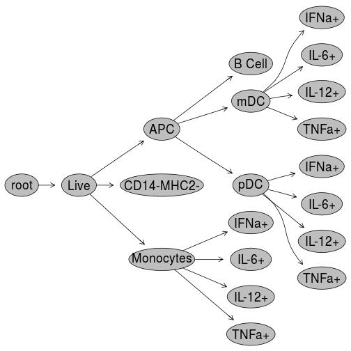

```r
plot(gs)
```

We can list the nodes (populations) in the gating hierarchy:

```r
getNodes(gs, path = 1)
```

```
##  [1] "root"       "Live"       "APC"        "B Cell"     "mDC"
##  [6] "IFNa+"      "IL-6+"      "IL-12+"     "TNFa+"      "pDC"
## [11] "IFNa+"      "IL-6+"      "IL-12+"     "TNFa+"      "CD14-MHC2-"
## [16] "Monocytes"  "IFNa+"      "IL-6+"      "IL-12+"     "TNFa+"
```

Note that `path` argument specifies the depth of the gating path for each population. As shown, `depth` of `1` (i.e. leaf or terminal node name) may not be sufficient to uniquely identify each population. The issue can be resolved by increasing the `path` or simply returning the full path of the node:

```r
getNodes(gs, path = "full")
```

```
##  [1] "root"                   "/Live"
##  [3] "/Live/APC"              "/Live/APC/B Cell"
##  [5] "/Live/APC/mDC"          "/Live/APC/mDC/IFNa+"
##  [7] "/Live/APC/mDC/IL-6+"    "/Live/APC/mDC/IL-12+"
##  [9] "/Live/APC/mDC/TNFa+"    "/Live/APC/pDC"
## [11] "/Live/APC/pDC/IFNa+"    "/Live/APC/pDC/IL-6+"
## [13] "/Live/APC/pDC/IL-12+"   "/Live/APC/pDC/TNFa+"
## [15] "/Live/CD14-MHC2-"       "/Live/Monocytes"
## [17] "/Live/Monocytes/IFNa+"  "/Live/Monocytes/IL-6+"
## [19] "/Live/Monocytes/IL-12+" "/Live/Monocytes/TNFa+"
```

But `full` path may not be neccessary and could be too long to be visualized. So we provide the `path = 'auto'` option to determine the shortest path that is still unique within the gating tree.

```r
nodelist <- getNodes(gs, path = "auto")
nodelist
```

```
##  [1] "root"             "Live"             "APC"
##  [4] "B Cell"           "mDC"              "mDC/IFNa+"
##  [7] "mDC/IL-6+"        "mDC/IL-12+"       "mDC/TNFa+"
## [10] "pDC"              "pDC/IFNa+"        "pDC/IL-6+"
## [13] "pDC/IL-12+"       "pDC/TNFa+"        "CD14-MHC2-"
## [16] "Monocytes"        "Monocytes/IFNa+"  "Monocytes/IL-6+"
## [19] "Monocytes/IL-12+" "Monocytes/TNFa+"
```

We can get the gate associated with the specific population:

```r
node <- nodelist[3]
g <- getGate(gs, node)
g
```

```
## $a2004_O1T2pb05i_A1_A01.fcs_61832
## Polygonal gate 'APC' with 14 vertices in dimensions <PerCP-CY5-5-A> and <PE-CY7-A>
##
## $a2004_O1T2pb05i_A2_A02.fcs_45363
## Polygonal gate 'APC' with 14 vertices in dimensions <PerCP-CY5-5-A> and <PE-CY7-A>
```

We can retrieve the population statistics :

```r
getPopStats(gs)[1:10,]
```

```
##                                 name Population Parent Count ParentCount
##  1: a2004_O1T2pb05i_A1_A01.fcs_61832       Live   root 49484       61832
##  2: a2004_O1T2pb05i_A1_A01.fcs_61832        APC   Live  4154       49484
##  3: a2004_O1T2pb05i_A1_A01.fcs_61832     B Cell    APC  2311        4154
##  4: a2004_O1T2pb05i_A1_A01.fcs_61832        mDC    APC   512        4154
##  5: a2004_O1T2pb05i_A1_A01.fcs_61832  mDC/IFNa+    mDC     2         512
##  6: a2004_O1T2pb05i_A1_A01.fcs_61832  mDC/IL-6+    mDC    22         512
##  7: a2004_O1T2pb05i_A1_A01.fcs_61832 mDC/IL-12+    mDC     2         512
##  8: a2004_O1T2pb05i_A1_A01.fcs_61832  mDC/TNFa+    mDC    72         512
##  9: a2004_O1T2pb05i_A1_A01.fcs_61832        pDC    APC   433        4154
## 10: a2004_O1T2pb05i_A1_A01.fcs_61832  pDC/IFNa+    pDC     0         433
```

We can plot individual gates: note the scale of the transformed axes. Second argument is the node path of any depths as long as it is uniquely identifieable.

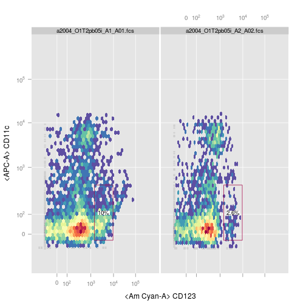

```r
plotGate(gs, "pDC")
```

More details about gate visualization can be found [here](http://bioconductor.org/packages/release/bioc/vignettes/flowWorkspace/inst/doc/plotGate.html).

If we have metadata associated with the experiment, it can be attached to the `GatingSet`.

```r
d <- data.frame(sample=factor(c("sample 1", "sample 2")),treatment=factor(c("sample","control")) )
pd <- pData(gs)
pd <- cbind(pd,d)
pData(gs) <- pd
pData(gs)
```

```
##                                                        name   sample
## a2004_O1T2pb05i_A1_A01.fcs_61832 a2004_O1T2pb05i_A1_A01.fcs sample 1
## a2004_O1T2pb05i_A2_A02.fcs_45363 a2004_O1T2pb05i_A2_A02.fcs sample 2
##                                  treatment
## a2004_O1T2pb05i_A1_A01.fcs_61832    sample
## a2004_O1T2pb05i_A2_A02.fcs_45363   control
```

We cann subset the `GatingSet` by its `pData` directly:

```r
subset(gs, treatment == "control")
```

```
## A GatingSet with 1 samples
```

The underling `flow data`(`flowSet` or `ncdfFlowSet` ) can be retrieved by:

```r
fs <- getData(gs)
class(fs)
```

```
## [1] "ncdfFlowSet"
## attr(,"package")
## [1] "ncdfFlow"
```

```r
nrow(fs[[1]])
```

```
## [1] 61832
```

Note that the data is already compensated and transformed during the parsing.

We can retrieve the subset of data associated with a population node:

```r
fs <- getData(gs, node)
nrow(fs[[1]])
```

```
## [1] 4154
```

## GatingHierarchy

We can retrieve a single gating hierarchical tree (corresponding to one sample) by `[[` operator

```r
gh <- gs[[1]]
gh
```

```
## Sample:  a2004_O1T2pb05i_A1_A01.fcs_61832
## GatingHierarchy with  20  gates
```

Note that the index can be either numeric or character (the `guid` returned by `sampleNames` method)

We can do similar operations on this `GatingHierarchy` object and same methods behave differently from `GatingSet`

```r
head(getPopStats(gh))
```

```
##    openCyto.freq    xml.freq openCyto.count xml.count      node
## 1:    1.00000000 1.000000000          61832     61832      root
## 2:    0.80029758 0.801235606          49484     49542      Live
## 3:    0.08394633 0.083585645           4154      4141       APC
## 4:    0.55633125 0.548418256           2311      2271    B Cell
## 5:    0.12325469 0.121226757            512       502       mDC
## 6:    0.00390625 0.003984064              2         2 mDC/IFNa+
```

Here `getPopStats` returns both the stats directly stored in `flowJo` xml workspace and one calcuated by `GatingSet` through the gating. There are could be minor difference between the two due to the numerical errors. However the difference should not be significant. Therore this can be used as the validity check for the parsing accuracy.

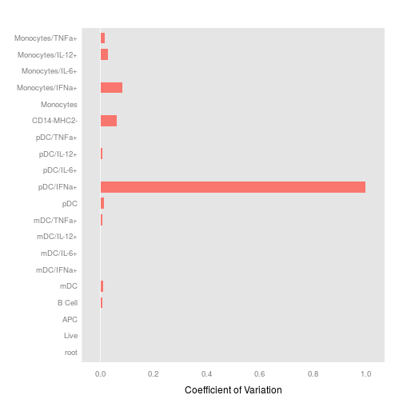

```r
plotPopCV(gh)
```

`plotGate` method without specifying any node will layout all the gates in the same plot

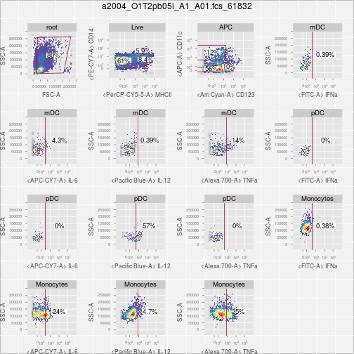

```r
plotGate(gh)
```

We can retrieve the indices specifying if an event is included inside or outside a gate using:

```r
table(getIndices(gh,node))
```

```
##
## FALSE  TRUE
## 57678  4154
```

We can retrieve all the compensation matrices from the `GatingHierarchy` in case we wish to use the compensation or transformation for the new data,

```r
C <- getCompensationMatrices(gh);
C
```

```
## Compensation object 'defaultCompensation':
##                Am Cyan-A Pacific Blue-A    APC-A APC-CY7-A Alexa 700-A
## Am Cyan-A        1.00000        0.04800 0.000000    0.0000     0.00000
## Pacific Blue-A   0.38600        1.00000 0.000529    0.0000     0.00000
## APC-A            0.00642        0.00235 1.000000    0.0611     0.19800
## APC-CY7-A        0.03270        0.02460 0.084000    1.0000     0.02870
## Alexa 700-A      0.07030        0.05800 0.016200    0.3990     1.00000
## FITC-A           0.74500        0.02090 0.001870    0.0000     0.00000
## PerCP-CY5-5-A    0.00368        0.00178 0.015300    0.0269     0.07690
## PE-CY7-A         0.01330        0.00948 0.000951    0.1380     0.00182
##                   FITC-A PerCP-CY5-5-A PE-CY7-A
## Am Cyan-A       0.028500       0.00104  0.00000
## Pacific Blue-A  0.000546       0.00000  0.00000
## APC-A          -0.000611       0.00776  0.00076
## APC-CY7-A       0.002690       0.00304  0.01010
## Alexa 700-A     0.001530       0.10800  0.00679
## FITC-A          1.000000       0.04180  0.00281
## PerCP-CY5-5-A   0.000000       1.00000  0.07030
## PE-CY7-A        0.002340       0.03360  1.00000
```

Or we can retrieve transformations:

```r
T <- getTransformations(gh)
names(T)
```

```
##  [1] "<Alexa 700-A>"    "<Am Cyan-A>"      "<APC-A>"
##  [4] "<APC-CY7-A>"      "<FITC-A>"         "<Pacific Blue-A>"
##  [7] "<PE-CY7-A>"       "<PerCP-CY5-5-A>"  "Alexa 700-H"
## [10] "Am Cyan-H"        "APC-CY7-H"        "APC-H"
## [13] "FITC-H"           "Pacific Blue-H"   "PE-CY7-H"
## [16] "PerCP-CY5-5-H"
```

```r
T[[1]]
```

```
## function (x, deriv = 0)
## {
##     deriv <- as.integer(deriv)
##     if (deriv < 0 || deriv > 3)
##         stop("'deriv' must be between 0 and 3")
##     if (deriv > 0) {
##         z0 <- double(z$n)
##         z[c("y", "b", "c")] <- switch(deriv, list(y = z$b, b = 2 *
##             z$c, c = 3 * z$d), list(y = 2 * z$c, b = 6 * z$d,
##             c = z0), list(y = 6 * z$d, b = z0, c = z0))
##         z[["d"]] <- z0
##     }
##     res <- stats:::.splinefun(x, z)
##     if (deriv > 0 && z$method == 2 && any(ind <- x <= z$x[1L]))
##         res[ind] <- ifelse(deriv == 1, z$y[1L], 0)
##     res
## }
## <bytecode: 0xa006bb0>
## <environment: 0xb24f790>
## attr(,"type")
## [1] "biexp"
## attr(,"parameters")
## attr(,"parameters")$channelRange
## [1] 4096
##
## attr(,"parameters")$maxValue
## [1] 262144
##
## attr(,"parameters")$neg
## [1] 0
##
## attr(,"parameters")$pos
## [1] 4.5
##
## attr(,"parameters")$widthBasis
## [1] -10
```

`getTransformations` returns a list of functions to be applied to different dimensions of the data. Above, the transformation is applied to this sample, the appropriate dimension is transformed using a channel–specific function from the list.

## Build the gating hierarchy from scratch

`GatingSet` provides methods to build a gating tree from raw FCS files and add or remove flowCore gates(or populations) to or from it.

```r
data(GvHD)
#select raw flow data
fs <- GvHD[1:2]
```

Then construct a \code{GatingSet} from \code{flowSet}:

```r
gs <- GatingSet(fs)
```

Then compensate it:

```r
cfile <- system.file("extdata","compdata","compmatrix", package="flowCore")
comp.mat <- read.table(cfile, header=TRUE, skip=2, check.names = FALSE)
## create a compensation object
comp <- compensation(comp.mat)
#compensate GatingSet
gs <- compensate(gs, comp)
```

**New**: You can now pass a list of `compensation` objects with elements named by `sampleNames(gs)` to achieve sample-specific compensations. e.g.

```r
gs <- compensate(gs, comp.list)
```

Then we can transform it with any transformation defined by user through `trans_new` function of `scales` package.

```r
require(scales)
trans.func <- asinh
inv.func <- sinh
trans.obj <- trans_new("myAsinh", trans.func, inv.func)
```

The `inverse` transformation is required so that the `gates` and data can be visualized in `transformed` scale with `axis` label still remains in the raw scale. Optionally `breaks` and `format` function can be supplied to further customize the appearance of axis labels.

Besides doing all these by hand, we also provide some buildin transformations: `asinhtGml2_trans`, `flowJo_biexp_trans`, `flowJo_fasinh_trans` and `logicle_trans`. These are all very commonly used transformations in flow data analysis. User can construct the transform object by simply one-line of code. e.g.

```r
trans.obj <- asinhtGml2_trans()
trans.obj
```

```
## Transformer:  asinhtGml2
```

Once `transformer` object is created, we must convert it to `transformerList` for `GatingSet` to use.

```r
chnls <- colnames(fs)[3:6]
transList <- transformerList(chnls, trans.obj)
```

Alternatively, the overloaded `estimateLogicle` method can be used directly on `GatingHierarchy` to generate a `transformerList` object automatically.

```r
estimateLogicle(gs[[1]], chnls)
```

```
## $`FL1-H`
## Transformer:  logicle
##
## $`FL2-H`
## Transformer:  logicle
##
## $`FL3-H`
## Transformer:  logicle
##
## $`FL2-A`
## Transformer:  logicle
##
## attr(,"class")
## [1] "transformerList" "list"
```

Now we can transform `GatingSet` with `transformerList` object. It will also store the transformation in the `GatingSet` and can be used to inverse-transform the data.

```r
gs <- transform(gs, transList)
getNodes(gs)
```

```
## [1] "root"
```

It now only contains the root node. We can add our first rectangleGate:

```r
rg <- rectangleGate("FSC-H"=c(200,400), "SSC-H"=c(250, 400), filterId="rectangle")
nodeID <- add(gs, rg)
nodeID
```

```
## [1] 2
```

```r
getNodes(gs)
```

```
## [1] "root"       "/rectangle"
```

Note that the gate is added to root node by default if parent is not specified. Then we add a quadGate to the new population generated by the rectangeGate which is named after filterId of the gate because the name is not specified when `add` method is called.

```r
qg <- quadGate("FL1-H"= 0.2, "FL2-H"= 0.4)
nodeIDs <- add(gs,qg,parent="rectangle")
nodeIDs
```

```
## [1] 3 4 5 6
```

```r
getNodes(gs)
```

```
## [1] "root"                          "/rectangle"
## [3] "/rectangle/CD15 FITC-CD45 PE+" "/rectangle/CD15 FITC+CD45 PE+"
## [5] "/rectangle/CD15 FITC+CD45 PE-" "/rectangle/CD15 FITC-CD45 PE-"
```

Here quadGate produces four population nodes/populations whose names are named after dimensions of gate if not specified.

Boolean Gate can also be defined and added to GatingSet:

```r
bg <- booleanFilter(`CD15 FITC-CD45 PE+|CD15 FITC+CD45 PE-`)
bg
```

```
## booleanFilter filter 'CD15 FITC-CD45 PE+|CD15 FITC+CD45 PE-' evaluating the expression:
## CD15 FITC-CD45 PE+|CD15 FITC+CD45 PE-
```

```r
nodeID2 <- add(gs,bg,parent="rectangle")
nodeID2
```

```
## [1] 7
```

```r
getNodes(gs)
```

```
## [1] "root"
## [2] "/rectangle"
## [3] "/rectangle/CD15 FITC-CD45 PE+"
## [4] "/rectangle/CD15 FITC+CD45 PE+"
## [5] "/rectangle/CD15 FITC+CD45 PE-"
## [6] "/rectangle/CD15 FITC-CD45 PE-"
## [7] "/rectangle/CD15 FITC-CD45 PE+|CD15 FITC+CD45 PE-"
```

The gating hierarchy is plotted by:

```r
plot(gs, bool=TRUE)
```

[output not shown]

Note that boolean gate is skipped by default and thus need to be enabled explictily.

Now all the gates are added to the gating tree but the actual data is not gated yet. This is done by calling `recompute` method explictily:

```r
recompute(gs)
```

After gating is finished,gating results can be visualized by `plotGate` method:

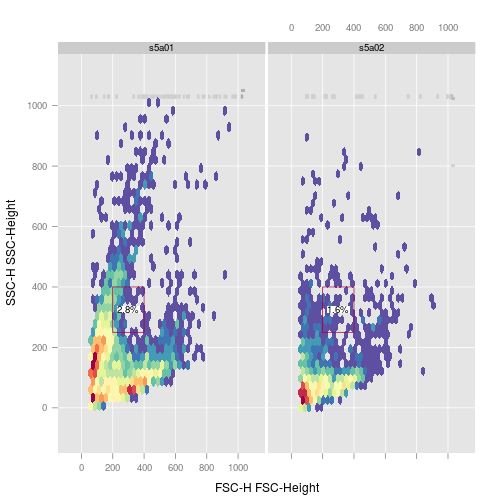

```r
plotGate(gs,"rectangle") #plot one Gate
```

Multiple gates can be plotted on the same pannel:

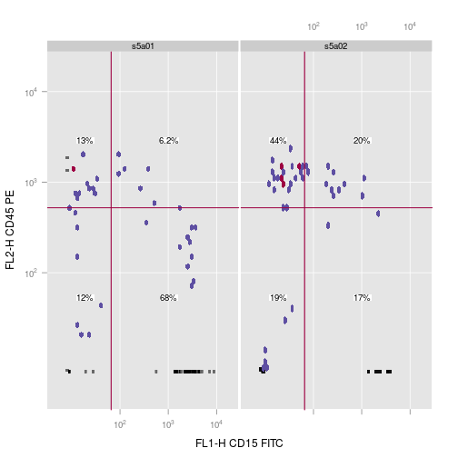

```r
plotGate(gs,getChildren(gs[[1]], "rectangle"))
```

We may also want to plot all the gates without specifying the gate index:

```r
plotGate(gs[[1]], bool=TRUE)
```

[output not shown]

If we want to remove one node, simply:

```r
Rm('rectangle', gs)
getNodes(gs)
```

```
## [1] "root"
```

As we see,removing one node causes all its descendants to be removed as well.

### archive and clone

Oftentime, we need to save a GatingSet including the gated flow data,gates and populations to disk and reload it later on. It can be done by:

```r
tmp <- tempdir()
save_gs(gs,path = file.path(tmp,"my_gs"))
gs <- load_gs(file.path(tmp,"my_gs"))
```

We also provide the `clone` method to make a full copy of an existing `GatingSet`:

```r
gs_cloned <- clone(gs)
```

Note that the `GatingSet` contains environment slots and external pointer that point to the internal C data structure. So make sure to use these methods in order to save or make a copy of existing object. The regular R assignment (<-) or `save` routine doesn't work as expected for the `GatingSet` object.

## Troubleshooting and error reporting

If this package is throwing errors when parsing your workspace, contact the package author by emails for post an issue on https://github.com/RGLab/flowWorkspace/issues. If you can send your workspace by email, we can test, debug, and fix the package so that it works for you. Our goal is to provide a tool that works, and that people find useful.